# Lab 4 Deliverable

Min Gao

4/24/2024

# Lab 4 Deliverable

## Part 1: Tidying

```r
gap_untidy <- read_excel("data/gapminder_broadband_per_100.xlsx")
glimpse(gap_untidy)
```

```
## Rows: 213
## Columns: 15
## $ `Fixed broadband Internet subscribers (per 100 people)` <chr> "Afghanistan",…
## $ `1998`                                                  <dbl> NA, NA, NA, NA…
## $ `1999`                                                  <dbl> NA, NA, NA, NA…
## $ `2000`                                                  <dbl> NA, NA, NA, NA…
## $ `2001`                                                  <dbl> 0.0000000000, …
## $ `2002`                                                  <dbl> 0.0000000000, …
## $ `2003`                                                  <dbl> 0.000000e+00, …
## $ `2004`                                                  <dbl> 6.880265e-04, …
## $ `2005`                                                  <dbl> 7.356639e-04, …
## $ `2006`                                                  <dbl> 0.001625928, N…
## $ `2007`                                                  <dbl> 0.001581161, 0…
## $ `2008`                                                  <dbl> 0.001537626, 2…
## $ `2009`                                                  <dbl> 0.00299058, 2.…
## $ `2010`                                                  <dbl> 0.004362367, 3…
## $ `2011`                                                  <lgl> NA, NA, NA, NA…
```

```r
gap <- gap_untidy %>% janitor::clean_names()
colnames(gap)[1] <- 'country'
gap %>%
  pivot_longer(-country, names_to = 'year', values_to="broadband") %>%
  drop_na()
```

```
## # A tibble: 2,108 × 3
##    country     year  broadband
##    <chr>       <chr>     <dbl>
##  1 Afghanistan x2001  0
##  2 Afghanistan x2002  0
##  3 Afghanistan x2003  0
##  4 Afghanistan x2004  0.000688
##  5 Afghanistan x2005  0.000736
##  6 Afghanistan x2006  0.00163
##  7 Afghanistan x2007  0.00158
##  8 Afghanistan x2008  0.00154
##  9 Afghanistan x2009  0.00299
## 10 Afghanistan x2010  0.00436
## # ℹ 2,098 more rows
```

## Part 2: Gapminder

Recall the Task Menu:

- Get the maximum and minimum of GDP per capita for all continents.

```r
library(gapminder)
glimpse(gapminder)
```

```
## Rows: 1,704
## Columns: 6
## $ country   <fct> "Afghanistan", "Afghanistan", "Afghanistan", "Afghanistan", …
## $ continent <fct> Asia, Asia, Asia, Asia, Asia, Asia, Asia, Asia, Asia, Asia, …
## $ year      <int> 1952, 1957, 1962, 1967, 1972, 1977, 1982, 1987, 1992, 1997, …
## $ lifeExp   <dbl> 28.801, 30.332, 31.997, 34.020, 36.088, 38.438, 39.854, 40.8…
## $ pop       <int> 8425333, 9240934, 10267083, 11537966, 13079460, 14880372, 12…
## $ gdpPercap <dbl> 779.4453, 820.8530, 853.1007, 836.1971, 739.9811, 786.1134, …
```

```r
gap_minder <-gapminder %>%
  select(year, continent, gdpPercap) %>%
  group_by(year,continent) %>%
  summarise_if(is.numeric, funs(min,max),na.rm = TRUE)
gap_select <- gap_minder %>% pivot_longer(min:max, names_to = "Min_Max", values_to="gdpPercap")
gap_select
```

```
## # A tibble: 120 × 4
## # Groups:   year [12]
##     year continent Min_Max gdpPercap
##    <int> <fct>     <chr>       <dbl>
##  1  1952 Africa    min          299.
##  2  1952 Africa    max         4725.
##  3  1952 Americas  min         1398.
##  4  1952 Americas  max        13990.
##  5  1952 Asia      min          331
##  6  1952 Asia      max       108382.
##  7  1952 Europe    min          974.
##  8  1952 Europe    max        14734.
##  9  1952 Oceania   min        10040.
## 10  1952 Oceania   max        10557.
## # ℹ 110 more rows
```

- Look at the spread of GDP per capita across countries within the continents.

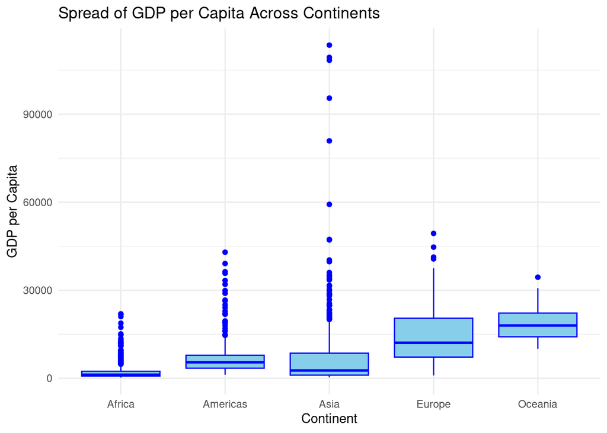

```r
gap_spread <-gapminder %>%
  select(year, continent, gdpPercap)

ggplot(gap_spread, aes(x=continent, y=gdpPercap))+
  geom_boxplot(fill = "skyblue", color = "blue")+
  labs(x = "Continent", y = "GDP per Capita") +
  ggtitle("Spread of GDP per Capita Across Continents") +
  theme_minimal()
```

- How does life expectancy vary across different continents?

```r
gap_life <-gapminder %>%
  select(continent,year,lifeExp)%>%
  group_by(year, continent)%>%
summarise(mean_life = mean(lifeExp),na.rm = TRUE)
glimpse(gap_life)
```

```
## Rows: 60
## Columns: 4
## Groups: year [12]
## $ year      <int> 1952, 1952, 1952, 1952, 1952, 1957, 1957, 1957, 1957, 1957, …
## $ continent <fct> Africa, Americas, Asia, Europe, Oceania, Africa, Americas, A…
## $ mean_life <dbl> 39.13550, 53.27984, 46.31439, 64.40850, 69.25500, 41.26635, …
## $ na.rm     <lgl> TRUE, TRUE, TRUE, TRUE, TRUE, TRUE, TRUE, TRUE, TRUE, TRUE, …
```

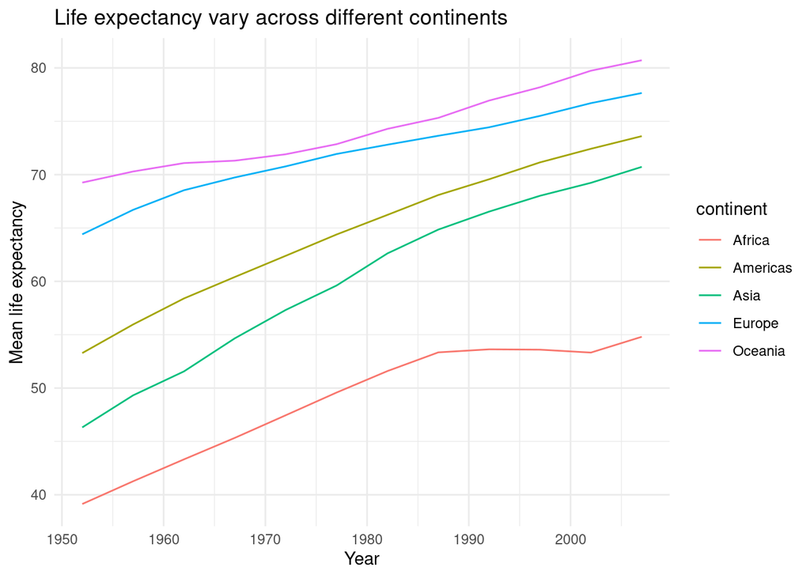

```r
ggplot(gap_life, aes(x = year, y = mean_life, color = continent)) +
  geom_line() +
  labs(x = "Year", y = "Mean life expectancy") +
  ggtitle("Life expectancy vary across different continents") +
  theme_minimal()
```

- Report the absolute and/or relative abundance of countries with low life expectancy over time by continent: Compute some measure of worldwide life expectancy - you decide - a mean or median or some other quantile or perhaps your current age. Then determine how many countries on each continent have a life expectancy less than this benchmark, for each year.
- Make up your own!

### Absolute Number of Countries Below Mean Life Expectancy by Continent

```r
gap_data <-gapminder %>%
  select(country,continent,year,lifeExp)
glimpse(gap_data)
```

```
## Rows: 1,704
## Columns: 4
## $ country   <fct> "Afghanistan", "Afghanistan", "Afghanistan", "Afghanistan", …
## $ continent <fct> Asia, Asia, Asia, Asia, Asia, Asia, Asia, Asia, Asia, Asia, …
## $ year      <int> 1952, 1957, 1962, 1967, 1972, 1977, 1982, 1987, 1992, 1997, …
## $ lifeExp   <dbl> 28.801, 30.332, 31.997, 34.020, 36.088, 38.438, 39.854, 40.8…
```

```r
mean_life_expectancy <- mean(gap_data$lifeExp, na.rm = TRUE)
countries_below_benchmark <- gap_data %>%
  group_by(year, continent) %>%
  summarise(countries_below_benchmark = sum(lifeExp < mean_life_expectancy, na.rm = TRUE))
```

#### Companion Graph

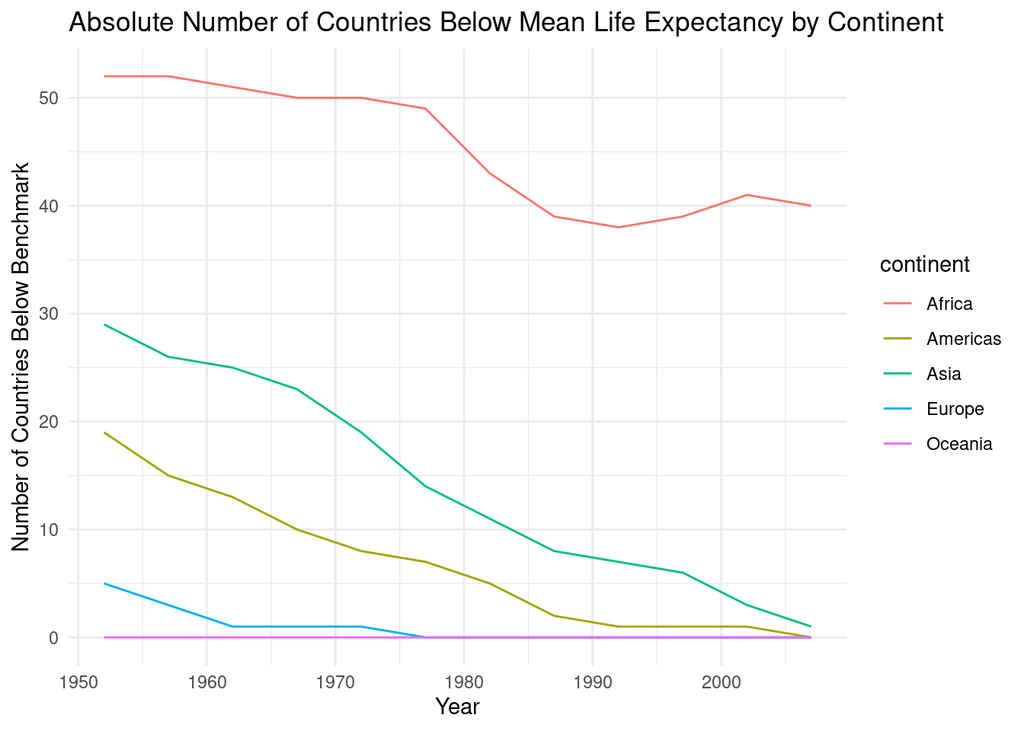

```r
ggplot(countries_below_benchmark, aes(x = year, y = countries_below_benchmark, color = continent)) +
  geom_line() +
  labs(x = "Year", y = "Number of Countries Below Benchmark") +
  ggtitle("Absolute Number of Countries Below Mean Life Expectancy by Continent") +
  theme_minimal()
```

#### Description/Writeup

Among all continents, Africa has the highest number of countries with life expectancy below the mean of worldwide over time. Oceania has the lowest number of countries with life expectancy below the mean of worldwide over time.

### Absolute Number of Countries Below 50 years life expectancy by Continent

```r
life_below_50 <- gap_data %>%
  group_by(year, continent) %>%
  summarise(life_below_50 = sum(lifeExp < 50, na.rm = TRUE))
```

#### Companion Graph

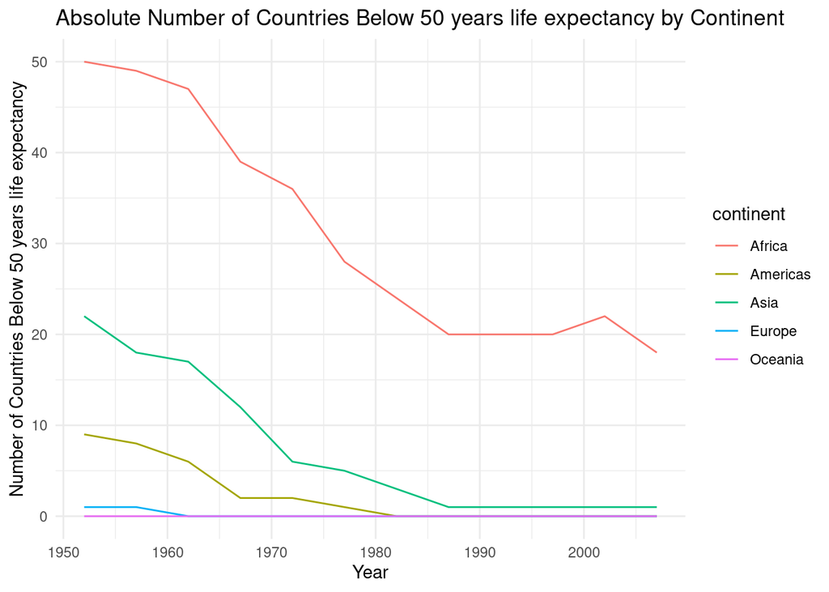

```r
ggplot(life_below_50, aes(x = year, y = life_below_50, color = continent)) +
  geom_line() +
  labs(x = "Year", y = "Number of Countries Below 50 years life expectancy") +
  ggtitle("Absolute Number of Countries Below 50 years life expectancy by Continent") +
  theme_minimal()
```

#### Description/Writeup

Over time, there has been a notable decline in the number of countries in Africa, the Americas, and Asia with life expectancy below 50 years. Conversely, in Europe and Oceania, there has been little significant change in the number of countries with life expectancy below 50 years.